# Defining hill farming

Mike Spencer

23 May 2018

## Introduction

### Purpose

This document is part of a project evaluating the importance of hill farming in Scottish communities. There is no existing classification of hill farming in Scotland, therefore an index of hill farming needed to be created to evalute its contribution. We chose to do this at an agricultural parish level using datasets describing landscape.

### Output level

Results will be aggregated to agricultural parishes, as this administrative level is widely understood and is appropriate for anonymising data. The 2016 agricultural parish data were downloaded from: https://data.gov.uk/dataset/939fdd5e-7322-4ab7-9dc9-bbfc538c4477/agricultural-parishes.

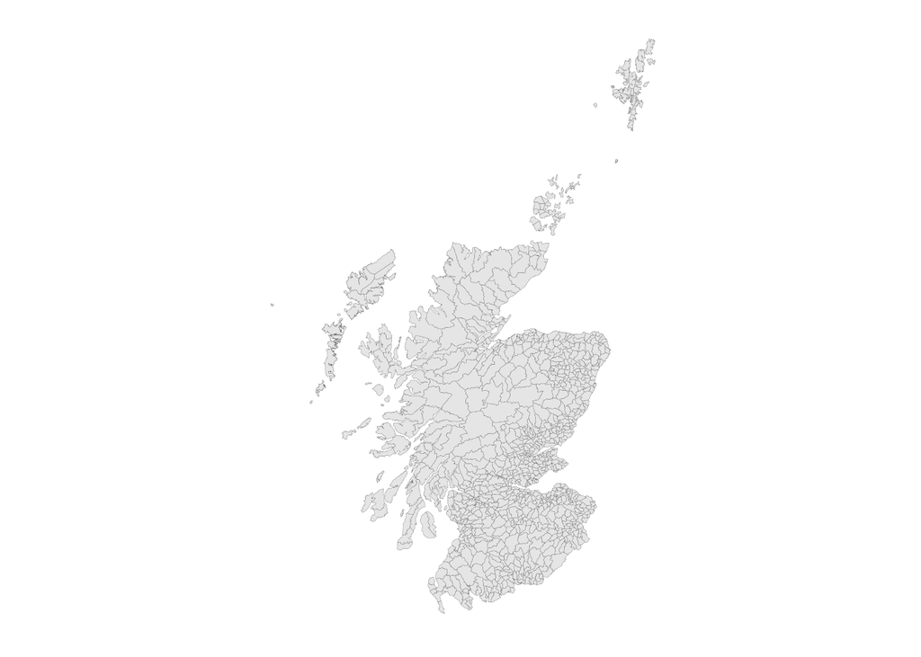

2016 agricultural parishes

The above map shows the 886 agricultural parishes in Scotland. These vary in size between 4.4 and 1121 km².

## Defining hill farming

A simple view of hill farming is of an activity which takes place in hills, but how are hills defined? Measuring hilliness by elevation would diminish the challenges of farming smaller hill areas like the Pentlands and Campsies, because they are a third of the height of the biggest mountains in Scotland. Incorporating slope into a measure of hill farming would help overcome using only elevation as a measure of hilliness because slopes can be steep without hills needing to be high.

There are many datasets available which we can use to further form an idea of hill farming areas. We have collected data from a variety of sources to help define hill farming:

- Elevation (including derived slope): https://www.ordnancesurvey.co.uk/business-and-government/products/terrain-50.html
- Scottish Natural Heritage (SNH) Landscape Character Assessment (LCA): https://gateway.snh.gov.uk/natural-spaces/
- SNH Carbon and Peatland map: https://gateway.snh.gov.uk/natural-spaces/
- James Hutton Institute (JHI) Land capability for agriculture: http://www.hutton.ac.uk/learning/natural-resource-datasets
- Agricultural census common and rough grazing: RESAS

### Definition method

Data described in the previous section were available in a range of formats, including raster (grid), vector (polygons) and plain text. In order to assess all these data at an agricultural parish level, these data were aggregated and converted to a common format. Following this process data were converted to a proportion of hilliness in each parish, e.g. for rural urban classification the proportion of each parish classified as rural was calculated.

Exact specification for this process is detailed in:

- `grass_read.R` which reads files into GRASS GIS
- `grass_analysis.R` clips polygon data to agricultural parishes and measures subsequent polygon sizes. Terrain values (elevation and slope) are also extracted from raster data.
- `read_hill_class.R` combines data from the GRASS analysis and aggregates to parish levels. Crucially, at a parish level proportion of land is reported as being less viable, i.e. higher proportions mean a parish is more likely to be hill farming.

### Terrain

The Ordnance Survey Terrain 50 digital elevation model was used to get terrain data for each parish. This gridded model has a 50 m cell resolution and each cell is attributed an average height of land contained within it. This elevation model was used to calculate slope, also on a 50 m grid. For the slope and elevation datasets summary values were extracted for each agricultural parish; these values were minimum, mean, median and maximum.

#### Elevation

Mean (average), median and maximum elevation are closely correlated, but there is variability between each of these and minimum elevation. This is due to within-parish elevation variation, e.g. some parishes will have a range from sea level to mountain top, but other parishes a occupy more level terrain. The elevation range within a parish could have been used, but this would largely duplicate slope, i.e. a big elevation range within a parish should produce a steeper slope.

Mean parish elevation has been chosen as a single measure of parish elevation. This because it is a central measure which captures the variation of the minimum, median and maximum best (correlations of 0.77, 0.99 and 0.94 respectively).

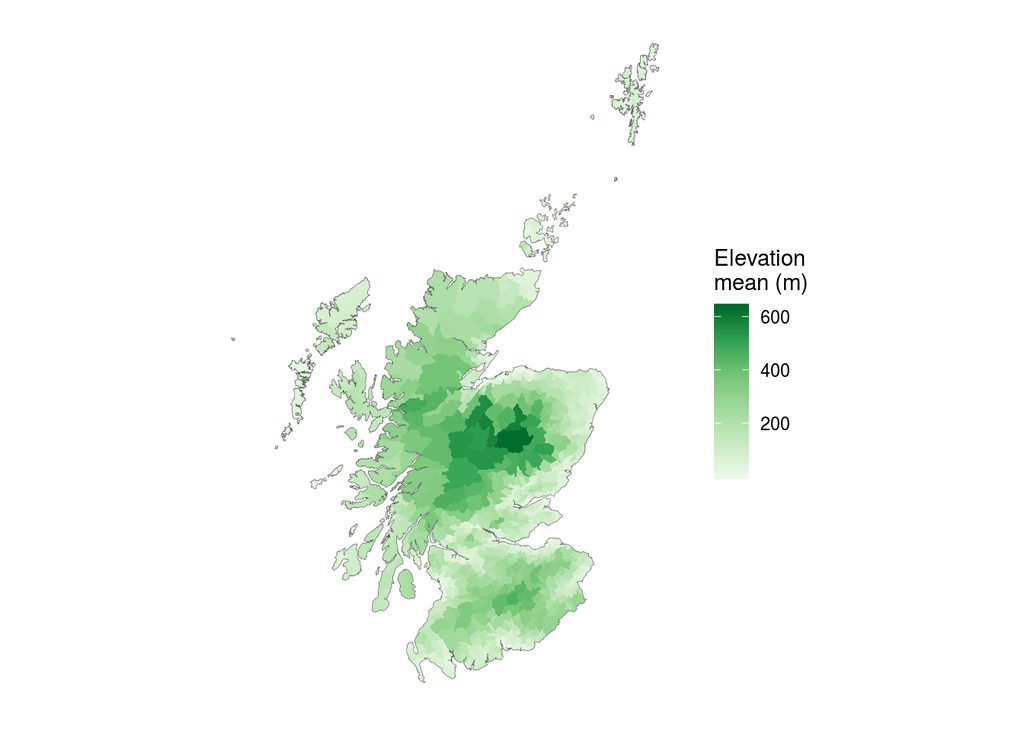

Map of mean parish elevation

#### Slope

As with elevation, the average (mean and median) slope measures correlate well. There is greater variability when compared to maximum slopes, but the largest variation is when comparing to minimum slopes.

A mean (average) slope has been used as a single parish slope indicator because it has the best correlation with median or maximum slope (0.98 and 0.71 respectively).

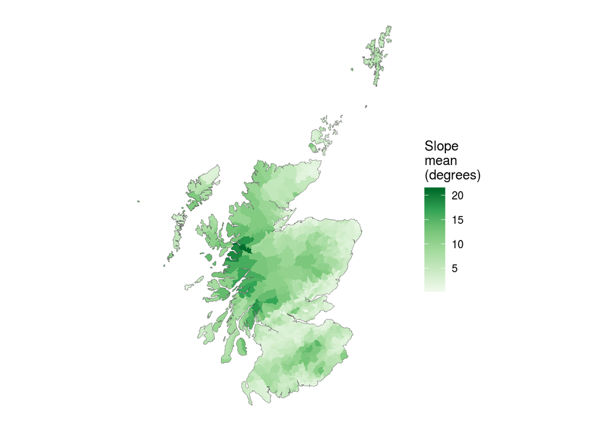

Map of mean parish slope

### Grazing

#### Common

The common grazing data were supplied by RESAS at a parish level in a csv format, so needed no format conversion or aggregation preparation. Common grazing data were sent with units of Hectares per parish, these were converted to m² before deriving proportion of common grazing within each parish. Common grazing is most dominant in the Outter Hebridies and North West Scotland.

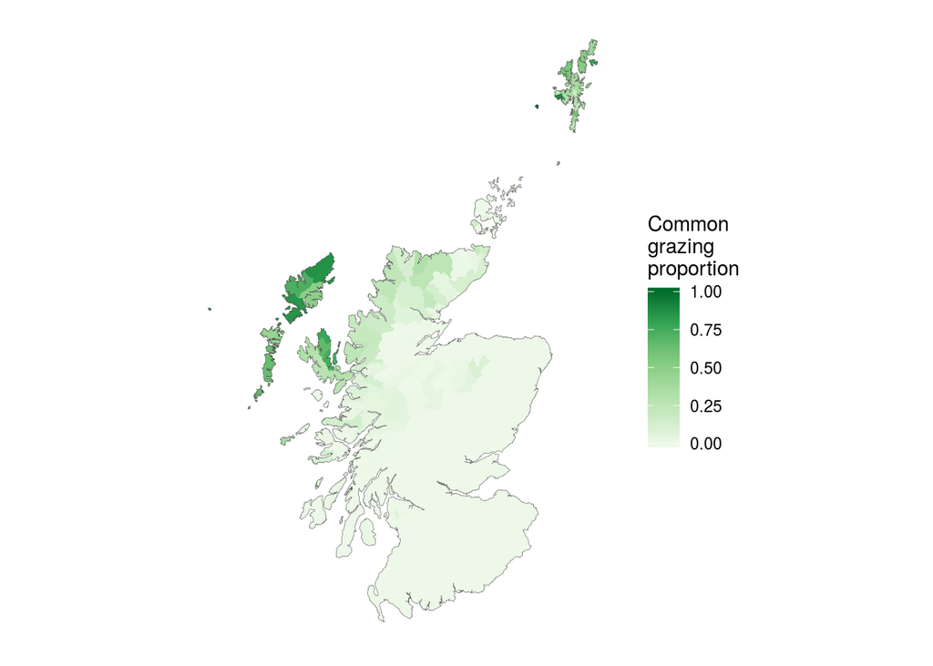

Map of parish common grazing proportion

#### Rough

Rough grazing areas were taken from the June Agricultural Census (2011).

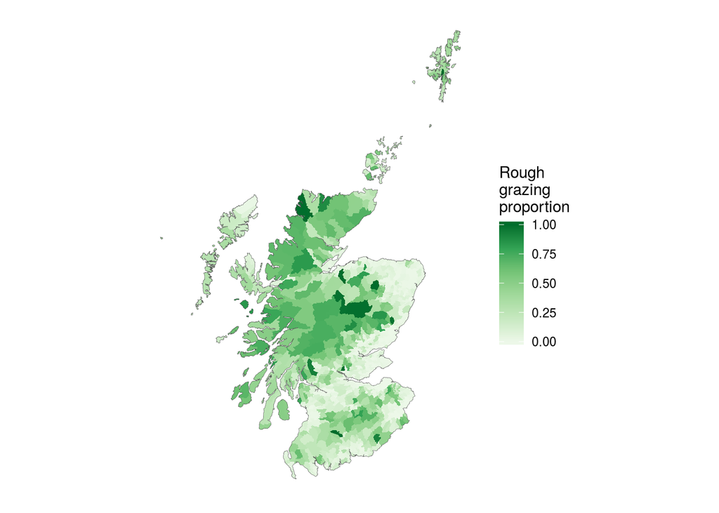

### SNH LCA Landscape Character Assessment

The SNH landscape character assessment has three levels. Level 1 has the most different landscape classes and level 3 has the least. As this work is concerned with aggregating data to define parishes, level 3 data were used as a hill farming indicator. Level 3 data were split as follows to define hill farming areas:

## Hill farming classes

Flat or Rolling, Smooth or Sweeping, Extensive, High Moorlands of the Highlands and Islands Inland Loch  
Highland Straths  
Moorland Transitional Landscapes of the Highlands and Islands  
High, Massive, Rolling, Rounded Mountains of the Highlands and Islands  
High Massive Mountain Plateau of the Cairngorms  
Smooth Upland Moorland Hills  
Highland Foothills  
Upland Igneous and Volcanic Hills The Ochil, Sidlaw, Cleish and Lomond Hills  
High, Massive, Rugged, Steep-Sided Mountains of the Highlands and Islands  
Sea Lochs of the Highlands and Islands  
Highland and Island Rocky Coastal Landscapes  
Peatland Landscapes of the Highlands and Islands  
Rocky Moorlands of the Highlands and Islands  
Rugged, Craggy Upland Hills and Moorlands of the Highlands, including the Trossachs  
Low Coastal Hills of the Highlands and Islands  
Coastal Hills Headlands Plateaux and Moorlands  
Lowland Hills  
Foothills and Pronounced Hills  
Upland Hills, The Southern Uplands and Cheviots  
High Plateau Moorlands  
Rugged Granite Uplands  
Rocky Volcanic Islands  
Rugged Moorland Hills  
Upland Fringe Moorland  
Upland Hills, The Lammemuir, Pentland and Moorfoot Hills  
Rocky Coasts Cliffs and Braes of the Lowlands  
Knock or Rock and Lochan of the Islands  
Highland Cnocan

## Not hill farming classes

Coastal Island  
Highland and Island Forested Landscape  
Highland and Island Crofting Landscapes  
Farmlands and Estates of the Highlands and Islands  
Highland and Island Glens  
Lowland Loch Basins  
Lowland Cities, Towns and Settlements  
Lowland River Valleys  
Low, Flat, and / or Sandy Coastal Landscapes of the Highlands and Islands Highland and Island Cities, Towns and Settlements  
Agricultural Lowlands of the North East  
Lowland Coastal Landscapes of the North East  
Lowland Valley Fringes  
Lowland Rolling or Undulating Farmlands, Hills and Valleys  
Flatter Wider Valleys and Floodplains of the Lowlands  
Coastal Raised Beaches and Terraces  
Lowland Hill Margins and Fringes  
Lowland Coastal Flats Sands and Dunes  
Lowland Loch and Shore  
Narrow Valleys in the Lowlands  
Coastal Margins  
Lowland Urbanised Landscapes  
Upland Glens, Valleys and Dales  
Upland Fringe Valleys and Farmlands  
Low Coastal Farmlands  
Lowland Plateaux and Plains  
Drumlin Lowlands  
Upland Basin

As can be seen, some of these descriptions are a little ambiguous. For example “Upland Basin” describes both a hill and glen feature.

Following this separation of landscape classes, the proportions in each parish were calculated, these are mapped below. The upland areas of the Cairngorms, Western Highlands and North West Scotland dominate this map.

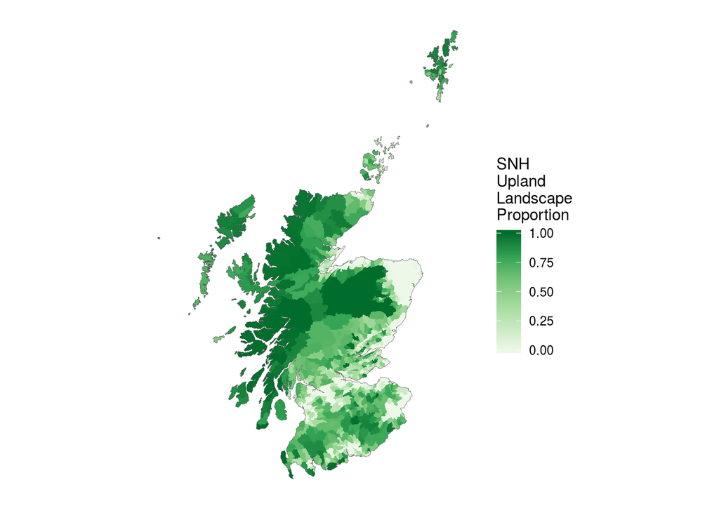

Map of parish SNH upland landscape proportion

### Carbon and peatland

SNH produce a map of carbon rich soils and peatland, these are polygon data with each polygon taking a categorical variable. These classifications were split into those with peat soils and those without. These classifications are listed below and are taken from the following report.

https://www.nature.scot/sites/default/files/2018-05/Carbon%20and%20Peatland%20map%20consultation%20analysis%20report.pdf

Hill farming

[output not shown]

Not hill farming

| Class | Description |
| --- | --- |
| -1 | Unknown soil type: information to be update when new data are released. |
| -2 | Non-soil: loch, built up area, rock and scree. |
| 0 | Mineral soils: peatland habitats are not typically found on such soils. |
| 4 | Area unlikely to be associated with peatland habitats or wet and acidic type. Area unlikely to include carbon-rich soils. |

Those believed to indicate hill farming constraints were used to calculate the proportion of agricultural parish within them and are plotted below. North West Scotland appears as the highest proportion using these measures.

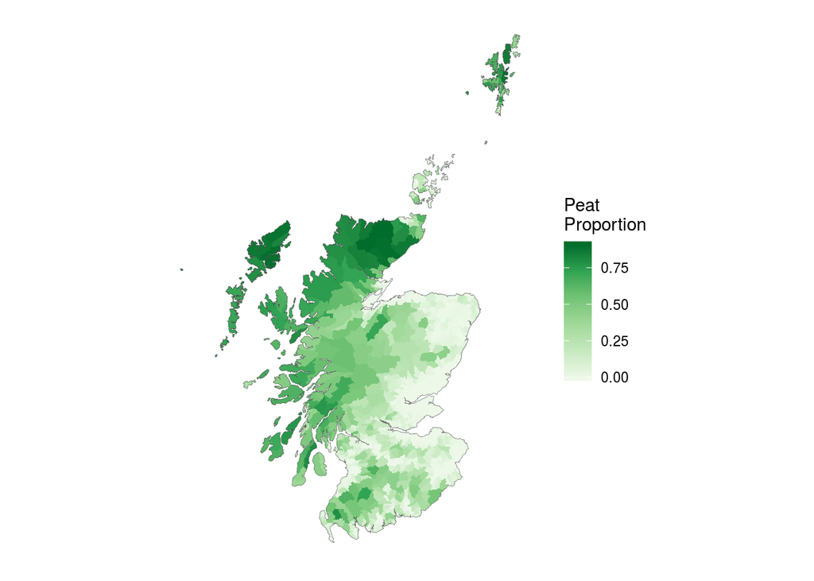

Map of parish SNH peat map proportion

### JHI LCA Land capability for agriculture

The James Hutton Institute produce a land capability index for agriculture based on soil, climate and relief. We downloaded the 1:250k resolution version, as it covers the whole of Scotland. The vector dataset classifies areas of Scotland by their agricultural capability, these classes are:

- Class 1. Land capable of producing a very wide range of crops with high yields
- Class 2. Land capable of producing a wide range of crops with yields less high than Class 1.
- Class 3. Land capable of producing good yields from a moderate range of crops.
- Class 4. Land capable of producing a narrow range of crops.
- Class 5. Land suited only to improved grassland and rough grazing.
- Class 6. Land capable only of use as rough grazing.
- Class 7. Land of very limited agricultural value.
- Classes >10. Urban areas, etc..

Polygons classed as 6 or 7 were aggregated and the proportion of agricultural parishes lying within them calculated. These are shown in the following map, which has the highest proportions in the central and western Highlands.

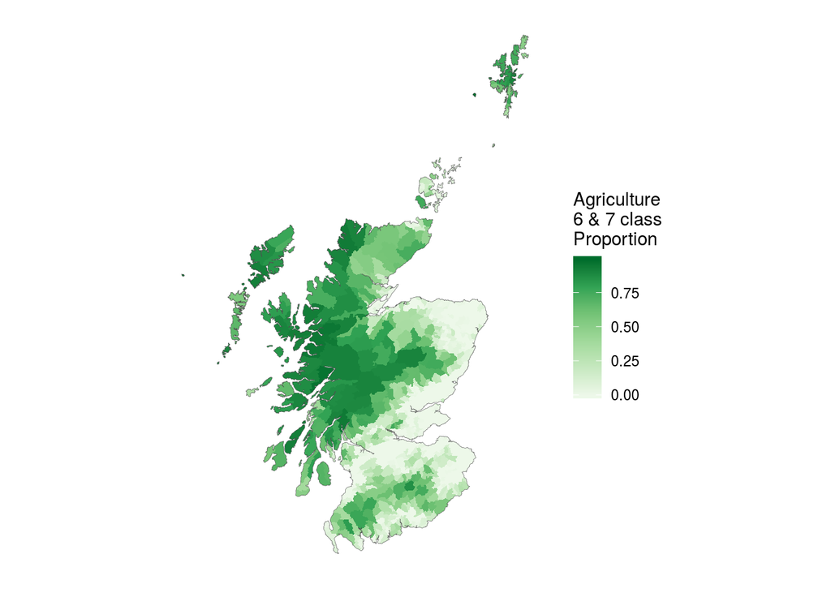

Map of parish JHI agricultural capability proportion

## Score and rank for the hilliness of each parish

The previous section describes a range of indices which can indicate hill farming areas. We have combined to produce a single index of hill farming areas.

The majority of the indicies have maximum values of one, because they show proportions. However, elevation and slope have maximum values above one. To create an unweighted index slope and elevation have been normalised by dividing values by their series maximums. These individual indicies were then summed for each parish to create a single index of hill farming for Scotland.

The results of this summation can be seen in the map below. The Cairngorms score highest, with areas in the central and western Highlands, North West Scotland and the Outer Hebridies also scoring highly.

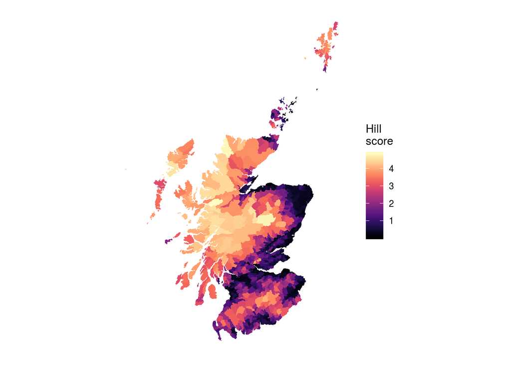

Map of parish hill farming index

The index of hill farming was ranked to show relative positions of each parish. These results are below:

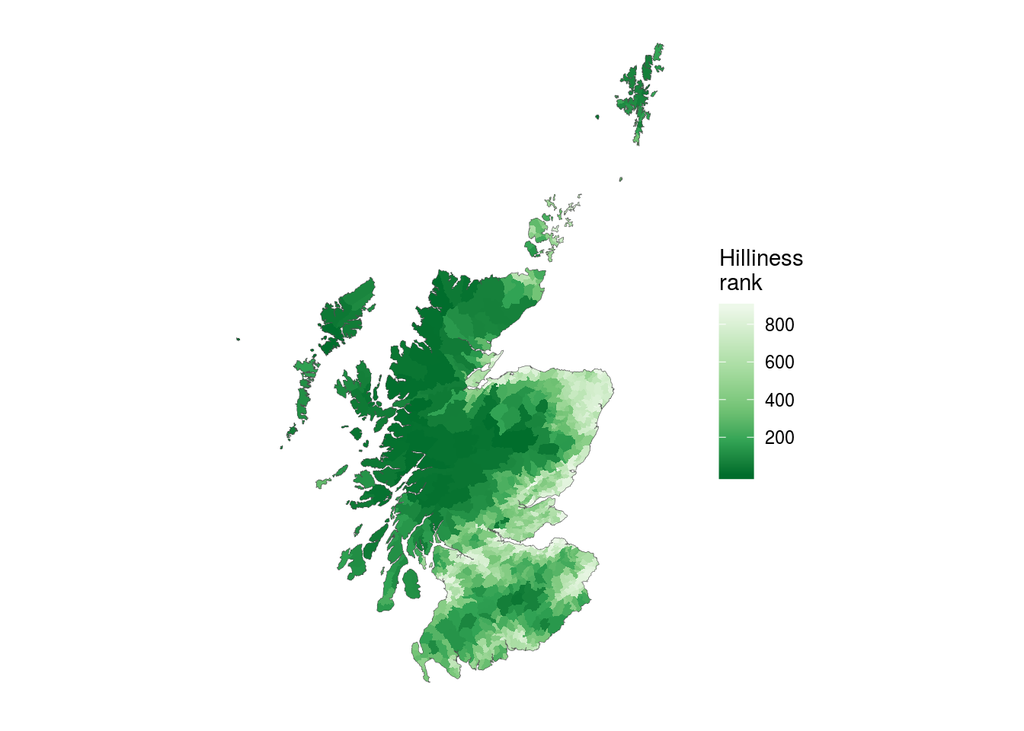

Map of parish hill farming index rank

The top 15 ranked parishes are:

```
## # A tibble: 15 x 1
##    PARName
##    <chr>
##  1 Crathie and Braemar
##  2 Ardgour
##  3 Alvie
##  4 Laggan
##  5 Harris
##  6 Glenelg
##  7 Kilmallie
##  8 Lochbroom
##  9 Applecross
## 10 Lochcarron
## 11 Contin
## 12 Glenshiel
## 13 Kintail
## 14 Assynt
## 15 Eddrachilles
```

## Group parishes into similar levels

We can use the individual indicies to group similar parishes together. First, we can inspect the relationships between indicies in the plot matrix below. Numbers in the upper right panels are Pearson correlations.

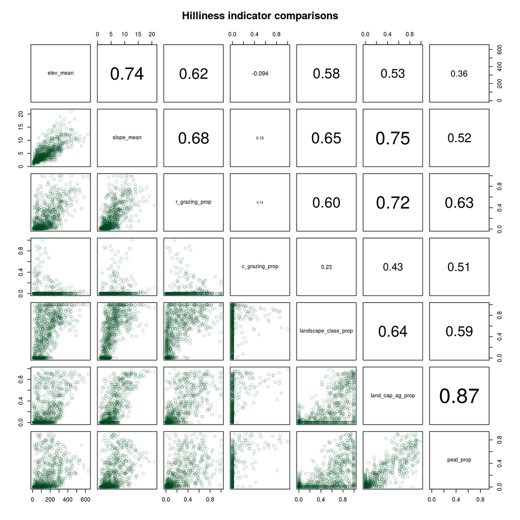

Comparison of hill farming indices by parish

The most well correlated variables are the JHI land capability indicies and the SNH Peat and Carbon map. These indicies use JHI soil data, so relationships are expected.

We can use a k-means model to group similar parishes together. K-means works by looking for common averages to cluster data points around. The following sections detail this work.

### Build k-means model

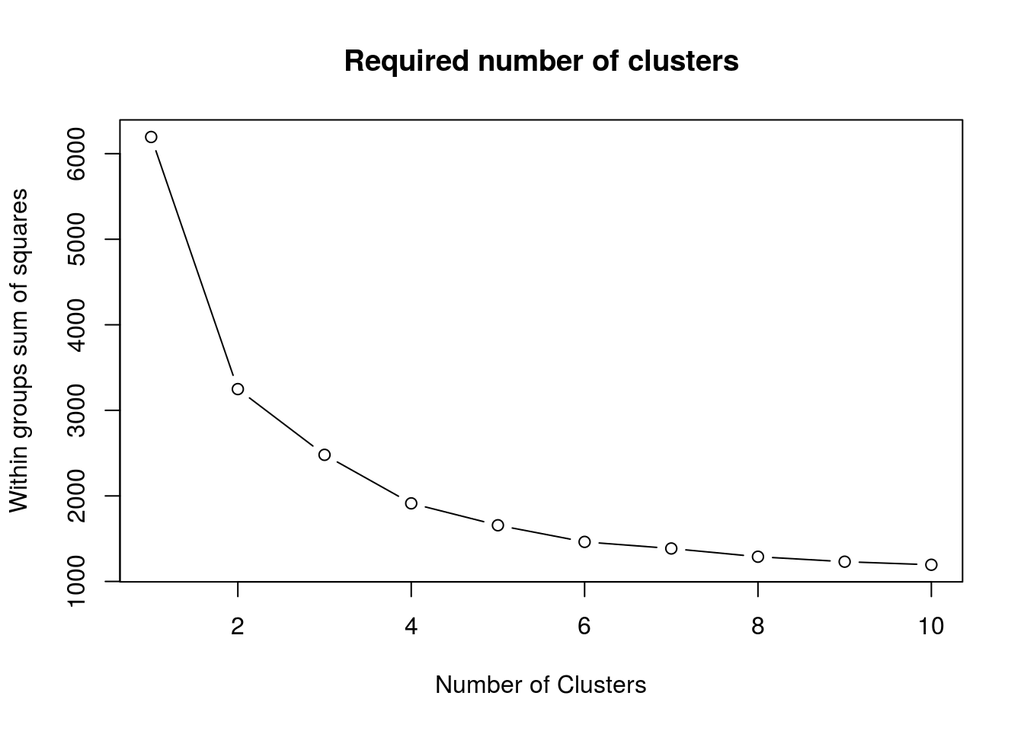

Elbow plot for determining optimal cluster number

These two clusters can then be mapped to our parishes as two levels: hill farming areas and not hill farming areas (below). As we expect, these are largely similar to the hill farming index, but partitioned into two groups.

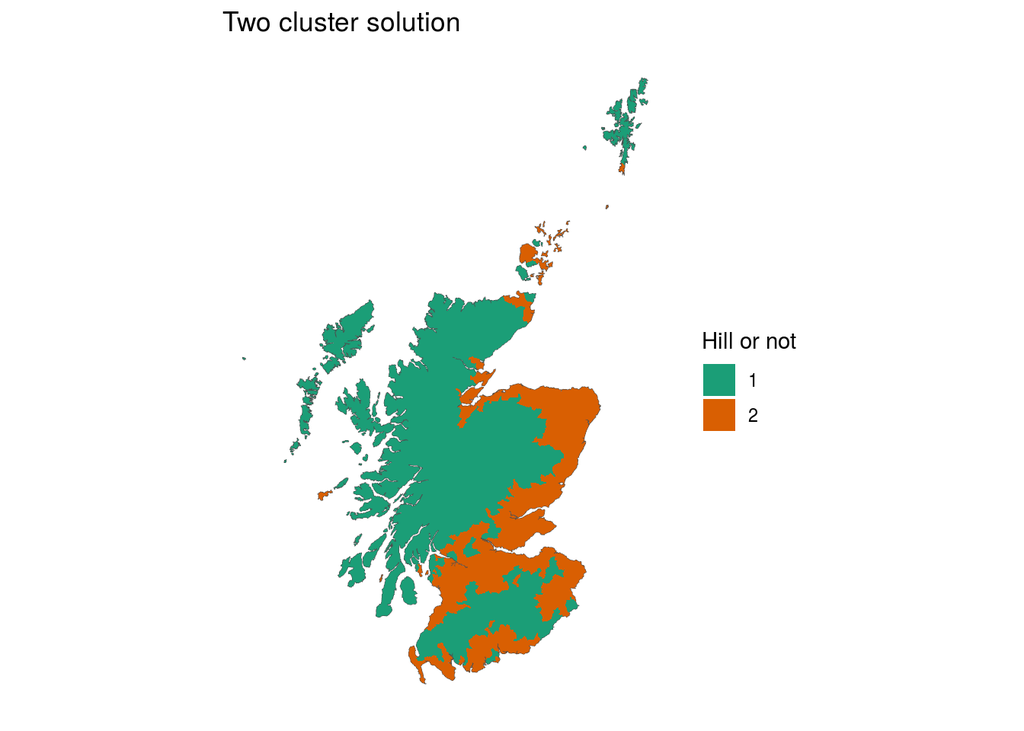

Map of parishes grouped by hill farming indices

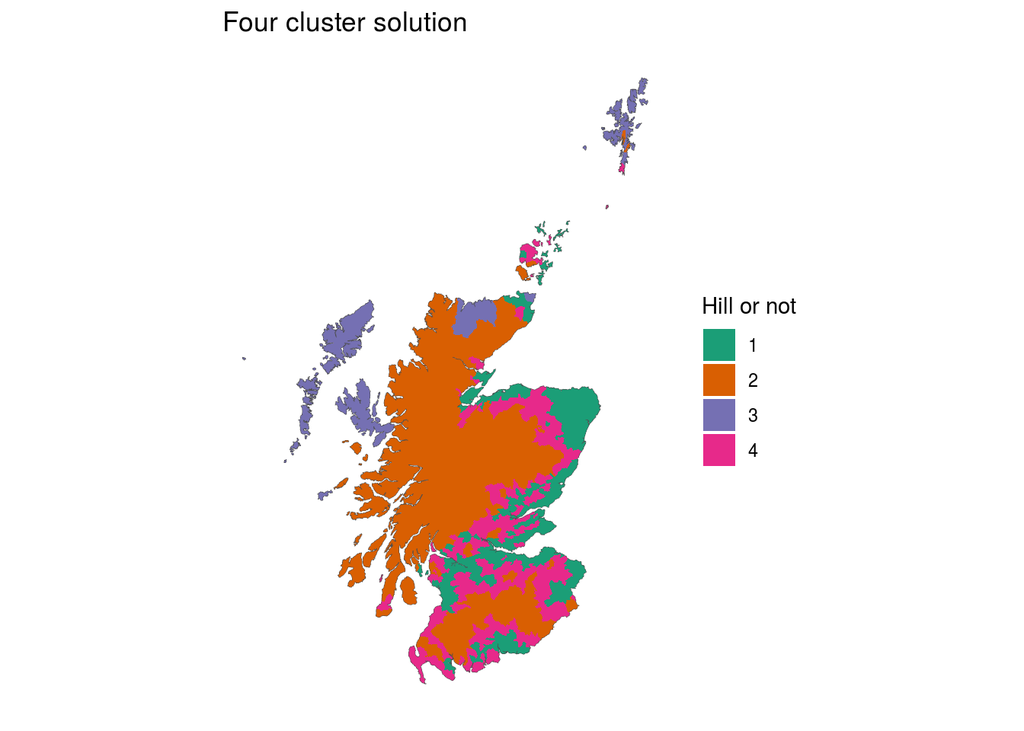

Map of parishes grouped by hill farming indices

We can see the difference in hill farming index against the two cluster groups below:

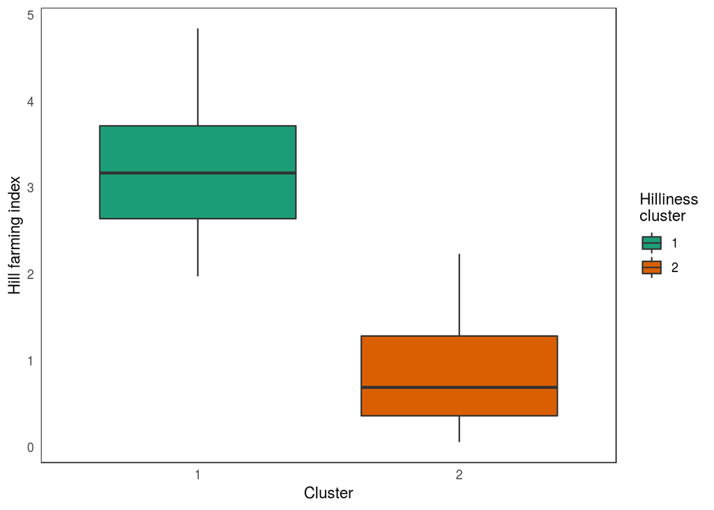

Plot comparing hill farming index to clusters of hill farming

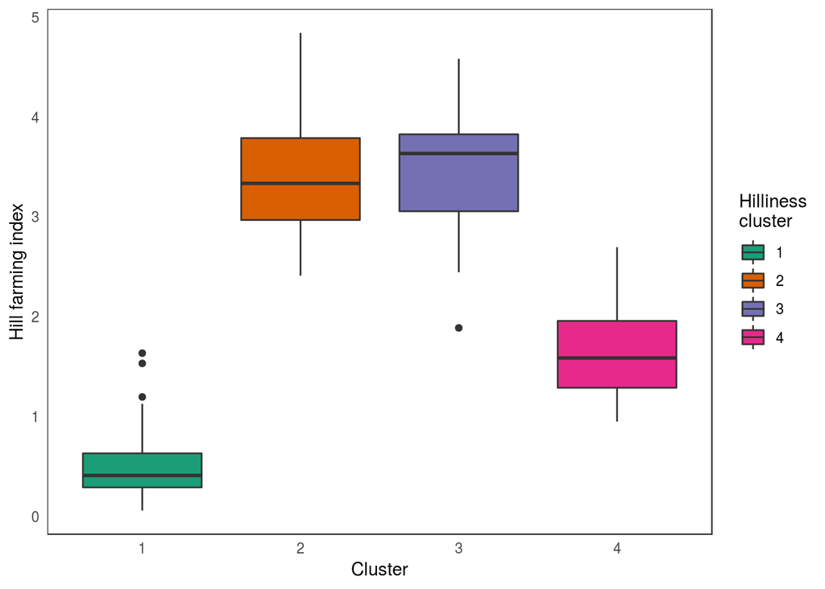

Plot comparing hill farming index to clusters of hill farming